# Practical Machine Learning - Course Project

Yanchenko Artem

```r
library(tidyverse)
library(caret)
```

## The task

Classify weightlifting activity according to one of 5 predefined classes of such activity.

## The data

The data was collected from accelerometers attached to the belt, forearm, arm, and dumbell of 6 participants. They were asked to perform one set of 10 repetitions of the Unilateral Dumbbell Biceps Curl in 5 different ways. Class A corresponds to the specified execution of the exercise, while the other 4 classes correspond to common mistakes: throwing the elbows to the front (Class B), lifting the dumbbell only halfway (Class C), lowering the dumbbell only halfway (Class D) and throwing the hips to the front (Class E).  
The data has already been split into training and testing sets.

```r
train_url <- "https://d396qusza40orc.cloudfront.net/predmachlearn/pml-training.csv"
test_url <- "https://d396qusza40orc.cloudfront.net/predmachlearn/pml-testing.csv"
download.file(train_url, "pml-training.csv")
download.file(test_url, "pml-testing.csv")
```

We read the datasets in.

```r
train_org <- read.csv("pml-training.csv", stringsAsFactors = FALSE, na.strings = c("", "NA"))
test_org <- read.csv("pml-testing.csv", stringsAsFactors = FALSE, na.strings = c("", "NA"))
```

## Explore the data

To avoid treating the test set as the train set and overfitting the model, we only conduct exploratory analysis and model training on the training set.

```r
str(train_org[,1:15])
```

```
'data.frame':   19622 obs. of  15 variables:
 $ X                   : int  1 2 3 4 5 6 7 8 9 10 ...
 $ user_name           : chr  "carlitos" "carlitos" "carlitos" "carlitos" ...
 $ raw_timestamp_part_1: int  1323084231 1323084231 1323084231 1323084232 1323084232 1323084232 1323084232 1323084232 1323084232 1323084232 ...
 $ raw_timestamp_part_2: int  788290 808298 820366 120339 196328 304277 368296 440390 484323 484434 ...
 $ cvtd_timestamp      : chr  "05/12/2011 11:23" "05/12/2011 11:23" "05/12/2011 11:23" "05/12/2011 11:23" ...
 $ new_window          : chr  "no" "no" "no" "no" ...
 $ num_window          : int  11 11 11 12 12 12 12 12 12 12 ...
 $ roll_belt           : num  1.41 1.41 1.42 1.48 1.48 1.45 1.42 1.42 1.43 1.45 ...
 $ pitch_belt          : num  8.07 8.07 8.07 8.05 8.07 8.06 8.09 8.13 8.16 8.17 ...
 $ yaw_belt            : num  -94.4 -94.4 -94.4 -94.4 -94.4 -94.4 -94.4 -94.4 -94.4 -94.4 ...
 $ total_accel_belt    : int  3 3 3 3 3 3 3 3 3 3 ...
 $ kurtosis_roll_belt  : chr  NA NA NA NA ...
 $ kurtosis_picth_belt : chr  NA NA NA NA ...
 $ kurtosis_yaw_belt   : chr  NA NA NA NA ...
 $ skewness_roll_belt  : chr  NA NA NA NA ...
```

There are character variables with “NA”. They should be converted to numerical type and removed, if percentage of NAs is too high.  
Classes of exercise execution mode are coded in `classe` variable.

```r
table(train_org$classe)
```

```
   A    B    C    D    E
5580 3797 3422 3216 3607
```

Summary of first few numerical variables.

```r
summary(train_org[,c(1,3,4,7:11)])
```

```
       X         raw_timestamp_part_1 raw_timestamp_part_2   num_window      roll_belt        pitch_belt
 Min.   :    1   Min.   :1.322e+09    Min.   :   294       Min.   :  1.0   Min.   :-28.90   Min.   :-55.8000
 1st Qu.: 4906   1st Qu.:1.323e+09    1st Qu.:252912       1st Qu.:222.0   1st Qu.:  1.10   1st Qu.:  1.7600
 Median : 9812   Median :1.323e+09    Median :496380       Median :424.0   Median :113.00   Median :  5.2800
 Mean   : 9812   Mean   :1.323e+09    Mean   :500656       Mean   :430.6   Mean   : 64.41   Mean   :  0.3053
 3rd Qu.:14717   3rd Qu.:1.323e+09    3rd Qu.:751891       3rd Qu.:644.0   3rd Qu.:123.00   3rd Qu.: 14.9000
 Max.   :19622   Max.   :1.323e+09    Max.   :998801       Max.   :864.0   Max.   :162.00   Max.   : 60.3000
    yaw_belt       total_accel_belt
 Min.   :-180.00   Min.   : 0.00
 1st Qu.: -88.30   1st Qu.: 3.00
 Median : -13.00   Median :17.00
 Mean   : -11.21   Mean   :11.31
 3rd Qu.:  12.90   3rd Qu.:18.00
 Max.   : 179.00   Max.   :29.00
```

Magnitudes of numerical sensor recorded values differ too much. It would make sense to normalize them and apply log transformation, which doesn’t change order of the data.  
We have 6 participants, whos’ names are in `user_name` variable.

```r
table(train_org$user_name)
```

```
  adelmo carlitos  charles   eurico   jeremy    pedro
    3892     3112     3536     3070     3402     2610
```

Since all participants were given the same task, we would expect that number of entries for each participant to be the same, but they range from 2610 to 3892.  
Each entry (observation) in fact is a measurement taken every fraction of second during activity execution.

There are 3 variables covering time attribute of the study. These are important variables, because all measurements were collected over the time of performing an activity, which makes the data time series data effectively.

```r
act_time_range <- c(adelmo = range(train_org$cvtd_timestamp[train_org$user_name == "adelmo"]),
            carlitos = range(train_org$cvtd_timestamp[train_org$user_name == "carlitos"]),
            charles = range(train_org$cvtd_timestamp[train_org$user_name == "charles"]),
            eurico = range(train_org$cvtd_timestamp[train_org$user_name == "eurico"]),
            jeremy = range(train_org$cvtd_timestamp[train_org$user_name == "jeremy"]),
            pedro = range(train_org$cvtd_timestamp[train_org$user_name == "pedro"]))
act_time_range
```

```
           adelmo1            adelmo2          carlitos1          carlitos2           charles1           charles2
"02/12/2011 13:32" "02/12/2011 13:35" "05/12/2011 11:23" "05/12/2011 11:25" "02/12/2011 14:56" "02/12/2011 14:59"
           eurico1            eurico2            jeremy1            jeremy2             pedro1             pedro2
"28/11/2011 14:13" "28/11/2011 14:15" "30/11/2011 17:10" "30/11/2011 17:12" "05/12/2011 14:22" "05/12/2011 14:24"
```

Looks like it took every participant about 2-3 minutes to perform all 50 repetitions (5 sets of 10 repetitions). So they must have performed them back-to-back, without rest.  
I would have treated this data as time series data, but the final goal of this project is to predict activity mode for 20 observations sampled from the original dataset. Each such observation corresponds to a moment in time, not a full repetition.  
It looks like one set of repetitions lasts roughly 20 to 25 units of `raw_timestamp_part_1` on average.  
But `raw_timestamp_part_2` represents much more precise time scale.

In this dataset we have 3 different timescales: `raw_timestamp_part_1`, `raw_timestamp_part_2` and `cvtd_timestamp`.  
`raw_timestamp_part_1` represents continuous real time, `cvtd_timestamp` - carries the same information as the previous variable converted to POSIXt format, `raw_timestamp_part_2` - represents local timescale of each activity mode (in milliseconds). The `raw_timestamp_part_2` variable can be useful for prediction in case if participants performed modes of the activity in the same order, but we don’t know that.  
These are important variables, but given the nature of the task, I think it makes sense to drop them altogether.  
Imagine a classifier that would split the data based on the certain value of `raw_timestamp_part_1`. Such a split would be irrelevant for a different participant, who performed the activity on different day and time.

## Missing values

Many machine learning algorithms are sensitive to missing values, so they should be taken care of.

```r
train_org <- train_org %>% mutate_at(c(12:159), as.numeric)
train_org <- train_org %>% mutate_at(c(2, 5, 6, 160), factor)
na_vars <- apply(train_org, 2, function(x) {sum(is.na(x))})
```

There are 100 variables that have more than 50% of NAs.  
It makes sense to remove such variables from the data set.

```r
train_cln <- train_org[,-c(which(na_vars > (nrow(train_org)/2)))]
cat("Number of NAs left in the data set now is", sum(is.na(train_cln)))
```

```
Number of NAs left in the data set now is 0
```

## Preprocessig

We will use `caret` package to build and tune the model.  
First, we normalize numeric variables and transform them, so all values are within the range of 0 to 1.

```r
prepr_obj <- preProcess(train_cln, method=c("YeoJohnson", "range"))
train_cln <- predict(prepr_obj, train_cln)
```

## Checking for near zero covariates

Here, we identify near zero covariate variables and remove them.

```r
nzv <- nearZeroVar(train_cln)
cat("Near zero covariates found:", names(train_cln[nzv]))
```

```
Near zero covariates found: new_window
```

```r
train_cln <- train_cln[,-nzv]
```

## Dealing with factor variables

```r
dum_vars <- dummyVars(classe ~ user_name, data=train_cln, fullRank = FALSE)
dummies <- data.frame(predict(dum_vars, newdata=train_cln))
```

## Assembling model ready dataset

```r
train_mdr <- cbind(dummies, train_cln[,c(6:59)])
```

## Preprocess test set

To make the test set ready for model evaluation we need to preprocess it the same way we have the train set.

```r
test_cln <- test_org %>% mutate_at(c(12:159), as.numeric)
test_cln <- test_org %>% mutate_at(c(2, 5, 6, 160), factor)
na_vars2 <- apply(test_cln, 2, function(x) {sum(is.na(x))})
test_cln <- test_cln[,-c(which(na_vars2 > (nrow(test_cln)/2)))]
test_cln <- predict(prepr_obj, test_cln)
nzv2 <- nearZeroVar(test_cln)
test_cln <- test_cln[,-nzv2]
dum_vars2 <- dummyVars( ~ user_name, data=test_cln, fullRank = FALSE)
dummies2 <- data.frame(predict(dum_vars2, newdata=test_cln))
test_mdr <- cbind(dummies2, test_cln[,c(6:59)])
```

## Split data - create validation set

Since training set is quite large, we can afford to set part of the data aside for model validation.  
This will allow us to get an unbiased estimation of out-of-sample error.

```r
train_indx <- createDataPartition(train_mdr$classe, times = 1, p=0.75, list = FALSE)
train_set <- train_mdr[train_indx,]
valid_set <- train_mdr[-train_indx,]
```

## Feature selection

Even after preprocessing the dataset still has 59 predictors. With the number of observations close to 20000 model evaluation can become quite computationaly demanding.  
To avoid that it makes sense to try to reduce the number of predictors.

```r
control_rfe <- rfeControl(functions = rfFuncs, method = "repeatedcv", repeats = 3, verbose = FALSE)
outcome_name <- "classe"
predictors <- names(train_set)[!names(train_set) %in% outcome_name]
pred_prof <- rfe(train_set[,predictors], train_set[,outcome_name], rfeControl = control_rfe)
pred_prof
```

```
Recursive feature selection

Outer resampling method: Cross-Validated (10 fold, repeated 3 times)

Resampling performance over subset size:

 Variables Accuracy  Kappa AccuracySD   KappaSD Selected
         4   0.9992 0.9990  0.0005662 0.0007162        *
         8   0.9985 0.9981  0.0009392 0.0011879
        16   0.9980 0.9974  0.0010998 0.0013909
        59   0.9973 0.9966  0.0009931 0.0012561

The top 4 variables (out of 4):
   num_window, roll_belt, yaw_belt, magnet_dumbbell_z
```

As a result we have a short set of 4 predictors that achive 99.9% accuracy on the “training” set.

```r
short_list <- c("num_window", "roll_belt", "yaw_belt", "magnet_dumbbell_z")
```

## Train a model

```r
fitControl <- trainControl(method = "cv", number = 3)
tune_grid_rpart <- expand.grid(cp=c(0.01,0.05,0.1))
tune_grid_rf <- expand.grid(mtry=c(2, 3, 4))
tune_grid_gbm <- expand.grid(n.trees=c(20,50,100), shrinkage=c(0.01,0.08,0.5), n.minobsinnode = c(100,200,500),interaction.depth=c(1,3,6))
```

### Decision tree

We start by fitting CART (classification and regression tree) model.

```r
set.seed(1975)
trn_cart <- train(train_set[,short_list], train_set[,60], method="rpart", trControl = fitControl,
                   tuneGrid = tune_grid_rpart)
cat("In-sample accuracy of this model is", trn_cart$results$Accuracy[1], ", Kappa is", trn_cart$results$Kappa[1])
```

```
In-sample accuracy of this model is 0.8747798 , Kappa is 0.8417422
```

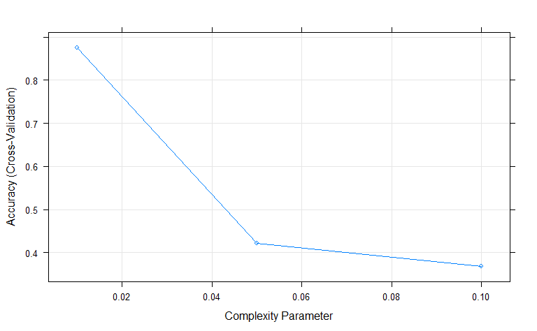

```r
plot(trn_cart)
```

Now we evaluate model performance by predicting on the “validation” set.  
This way we can get an estimate of the out-of-sample error rate, because “validation” set was not a part of data we used to train the model.

```r
pred_cart_val <- predict(trn_cart, valid_set[,-60], type = "raw")
confusionMatrix(pred_cart_val, valid_set[,60])
```

```
Confusion Matrix and Statistics

          Reference
Prediction    A    B    C    D    E
         A 1214   80    2   11    2
         B  108  864   82   72   80
         C   12    5  769   37   37
         D   10    0    2  646    9
         E   51    0    0   38  773

Overall Statistics

               Accuracy : 0.8699
                 95% CI : (0.8602, 0.8792)
    No Information Rate : 0.2845
    P-Value [Acc > NIR] : < 2.2e-16

                  Kappa : 0.8356
 Mcnemar's Test P-Value : < 2.2e-16

Statistics by Class:

                     Class: A Class: B Class: C Class: D Class: E
Sensitivity            0.8703   0.9104   0.8994   0.8035   0.8579
Specificity            0.9729   0.9135   0.9775   0.9949   0.9778
Pos Pred Value         0.9274   0.7164   0.8942   0.9685   0.8968
Neg Pred Value         0.9497   0.9770   0.9787   0.9627   0.9683
Prevalence             0.2845   0.1935   0.1743   0.1639   0.1837
Detection Rate         0.2476   0.1762   0.1568   0.1317   0.1576
Detection Prevalence   0.2669   0.2459   0.1754   0.1360   0.1758
Balanced Accuracy      0.9216   0.9120   0.9385   0.8992   0.9179
```

```r
prd_cart_test <- predict(trn_cart, test_mdr[,-60], type = "raw")
prd_cart_test
```

```
 [1] B A B A A E D B A A B C B A B E A B B B
Levels: A B C D E
```

## Random forest

```r
set.seed(1975)
trn_rf <- train(train_set[,short_list], train_set[,60], method = "rf", trControl = fitControl,
                  tuneGrid = tune_grid_rf)
cat("In-sample accuracy of this model is", trn_rf$results$Accuracy[1], ", Kappa is", trn_rf$results$Kappa[1])
```

```
In-sample accuracy of this model is 0.998641 , Kappa is 0.9982811
```

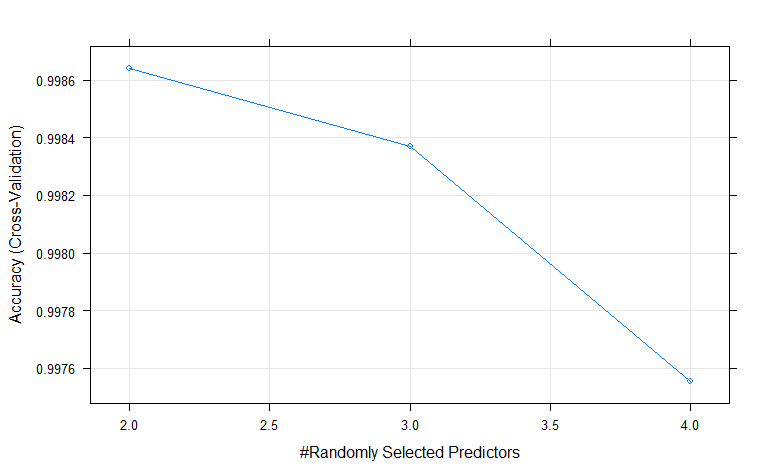

```r
plot(trn_rf)
```

Now we evaluate model performance by predicting on the “validation” set to get an estimation of out-of-sample error.

```r
pred_rf_val <- predict(trn_rf, valid_set[,-60], type = "raw")
confusionMatrix(pred_rf_val, valid_set[,60])
```

```
Confusion Matrix and Statistics

          Reference
Prediction    A    B    C    D    E
         A 1395    1    0    0    0
         B    0  948    0    0    0
         C    0    0  855    1    0
         D    0    0    0  800    6
         E    0    0    0    3  895

Overall Statistics

               Accuracy : 0.9978
                 95% CI : (0.996, 0.9989)
    No Information Rate : 0.2845
    P-Value [Acc > NIR] : < 2.2e-16

                  Kappa : 0.9972
 Mcnemar's Test P-Value : NA

Statistics by Class:

                     Class: A Class: B Class: C Class: D Class: E
Sensitivity            1.0000   0.9989   1.0000   0.9950   0.9933
Specificity            0.9997   1.0000   0.9998   0.9985   0.9993
Pos Pred Value         0.9993   1.0000   0.9988   0.9926   0.9967
Neg Pred Value         1.0000   0.9997   1.0000   0.9990   0.9985
Prevalence             0.2845   0.1935   0.1743   0.1639   0.1837
Detection Rate         0.2845   0.1933   0.1743   0.1631   0.1825
Detection Prevalence   0.2847   0.1933   0.1746   0.1644   0.1831
Balanced Accuracy      0.9999   0.9995   0.9999   0.9968   0.9963
```

This model achieved almost perfect accuracy of 99.78% on “validation” set.  
Now, we predict on the “test” set.

```r
prd_rf_test <- predict(trn_rf, test_mdr[,-60], type = "raw")
prd_rf_test
```

```
 [1] B A B A A E D B A A B C B A E E A B B B
Levels: A B C D E
```

### Generalized Boosting Model

```r
set.seed(1975)
trn_gbm <- train(train_set[,short_list], train_set[,60], method = "gbm", verbose = FALSE, trControl = fitControl,
                  tuneGrid = tune_grid_gbm)
cat("In-sample accuracy of this model is", round(trn_gbm$results$Accuracy[which.max(trn_gbm$results$Accuracy)], 4),
    ", Kappa is", round(trn_gbm$results$Kappa[which.max(trn_gbm$results$Kappa)], 4))
```

```
In-sample accuracy of this model is 0.9988 , Kappa is 0.9985
```

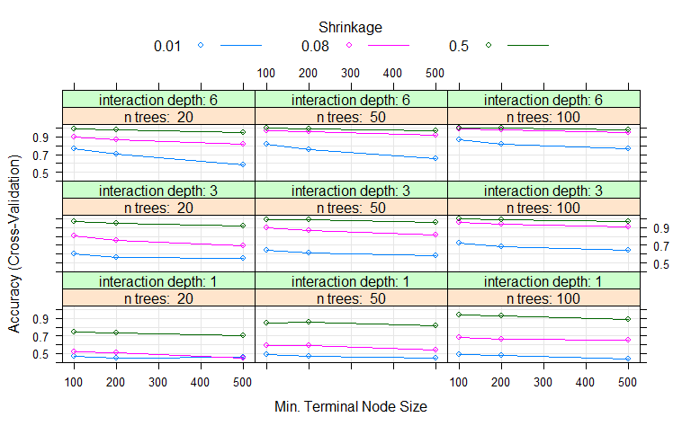

```r
plot(trn_gbm)
```

Now we evaluate model performance by predicting on the “validation” set.

```r
pred_gbm_val <- predict(trn_gbm, valid_set[,-60], type = "raw")
confusionMatrix(pred_gbm_val, valid_set[,60])
```

```
Confusion Matrix and Statistics

          Reference
Prediction    A    B    C    D    E
         A 1395    1    0    0    0
         B    0  948    0    0    0
         C    0    0  855    0    0
         D    0    0    0  801    6
         E    0    0    0    3  895

Overall Statistics

               Accuracy : 0.998
                 95% CI : (0.9963, 0.999)
    No Information Rate : 0.2845
    P-Value [Acc > NIR] : < 2.2e-16

                  Kappa : 0.9974
 Mcnemar's Test P-Value : NA

Statistics by Class:

                     Class: A Class: B Class: C Class: D Class: E
Sensitivity            1.0000   0.9989   1.0000   0.9963   0.9933
Specificity            0.9997   1.0000   1.0000   0.9985   0.9993
Pos Pred Value         0.9993   1.0000   1.0000   0.9926   0.9967
Neg Pred Value         1.0000   0.9997   1.0000   0.9993   0.9985
Prevalence             0.2845   0.1935   0.1743   0.1639   0.1837
Detection Rate         0.2845   0.1933   0.1743   0.1633   0.1825
Detection Prevalence   0.2847   0.1933   0.1743   0.1646   0.1831
Balanced Accuracy      0.9999   0.9995   1.0000   0.9974   0.9963
```

```r
prd_gbm_test <- predict(trn_gbm, test_mdr[,-60], type = "raw")
prd_gbm_test
```

```
 [1] B A B A A E D B A A B C B A E E A B B B
Levels: A B C D E
```

## Final prediction on the test set

Classes of “test” set observations predicted by “RF” and “GBM” models are in perfect agreement. “Rpart” method has also produced very similar predictions with just a few differences.  
Still, I’d like to formally combine predictions of the models built above and make them vote for the final predictions.  
First, we combine all predictions in a data frame.

```r
predictions_test <- data.frame(rbind(problem_id = test_org$problem_id, CART_pred = as.character(prd_cart_test), RF_pred = as.character(prd_rf_test), GBM_pred = as.character(prd_gbm_test), final_pred = NA))
```

Now, we pick the most common prediction for every “test” observation.

```r
for (i in 1:ncol(predictions_test)) {
      fp <- names(which.max(table(predictions_test[2:4,i])))
      predictions_test[5,i] <- fp
}
predictions_test[c(1,5),]
```

|  | X1 | X2 | X3 | X4 | X5 | X6 | X7 | X8 | X9 | X10 | X11 | X12 | X13 | X14 | X15 | X16 | X17 | X18 | X19 | X20 |
| --- | --- | --- | --- | --- | --- | --- | --- | --- | --- | --- | --- | --- | --- | --- | --- | --- | --- | --- | --- | --- |
| problem_id | 1 | 2 | 3 | 4 | 5 | 6 | 7 | 8 | 9 | 10 | 11 | 12 | 13 | 14 | 15 | 16 | 17 | 18 | 19 | 20 |
| final_pred | B | A | B | A | A | E | D | B | A | A | B | C | B | A | E | E | A | B | B | B |